# week11 async

K Iwasaki

August 2, 2017

Recap

```r
load("GPA1.rdata")
head(data)
```

```
##   age soph junior senior senior5 male campus business engineer colGPA
## 1  21    0      0      1       0    0      0        1        0    3.0
## 2  21    0      0      1       0    0      0        1        0    3.4
## 3  20    0      1      0       0    0      0        1        0    3.0
## 4  19    1      0      0       0    1      1        1        0    3.5
## 5  20    0      1      0       0    0      0        1        0    3.6
## 6  20    0      0      1       0    1      1        1        0    3.0
##   hsGPA ACT job19 job20 drive bike walk voluntr PC greek car siblings
## 1   3.0  21     0     1     1    0    0       0  0     0   1        1
## 2   3.2  24     0     1     1    0    0       0  0     0   1        0
## 3   3.6  26     1     0     0    0    1       0  0     0   1        1
## 4   3.5  27     1     0     0    0    1       0  0     0   0        1
## 5   3.9  28     0     1     0    1    0       0  0     0   1        1
## 6   3.4  25     0     0     0    0    1       0  0     0   1        1
##   bgfriend clubs skipped alcohol gradMI fathcoll mothcoll
## 1        0     0       2     1.0      1        0        0
## 2        1     1       0     1.0      1        1        1
## 3        0     1       0     1.0      1        1        1
## 4        0     0       0     0.0      0        0        0
## 5        1     0       0     1.5      1        1        0
## 6        0     0       0     0.0      0        1        0
```

```r
(model1 = lm(colGPA ~ ACT, data = data))
```

```
##
## Call:
## lm(formula = colGPA ~ ACT, data = data)
##
## Coefficients:
## (Intercept)          ACT
##     2.40298      0.02706
```

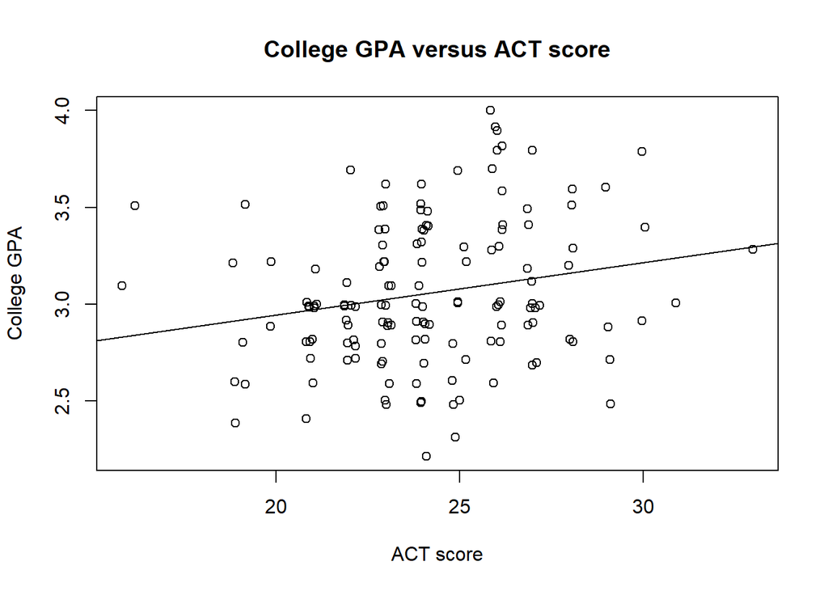

```r
plot(jitter(data$ACT), jitter(data$colGPA), xlab = "ACT score", ylab = "College GPA",
     main = "College GPA versus ACT score")
abline(model1)
```

## 11.14 Checking Unbiasedness in R (10:47)

1. Linear population model
2. Random sampling

Think about where the data is coming from. We cannot assess this assumption perfectly for this case.

3. Multicollinearity
4. Zero-conditional mean

We examine the residuals versus fitted values plot

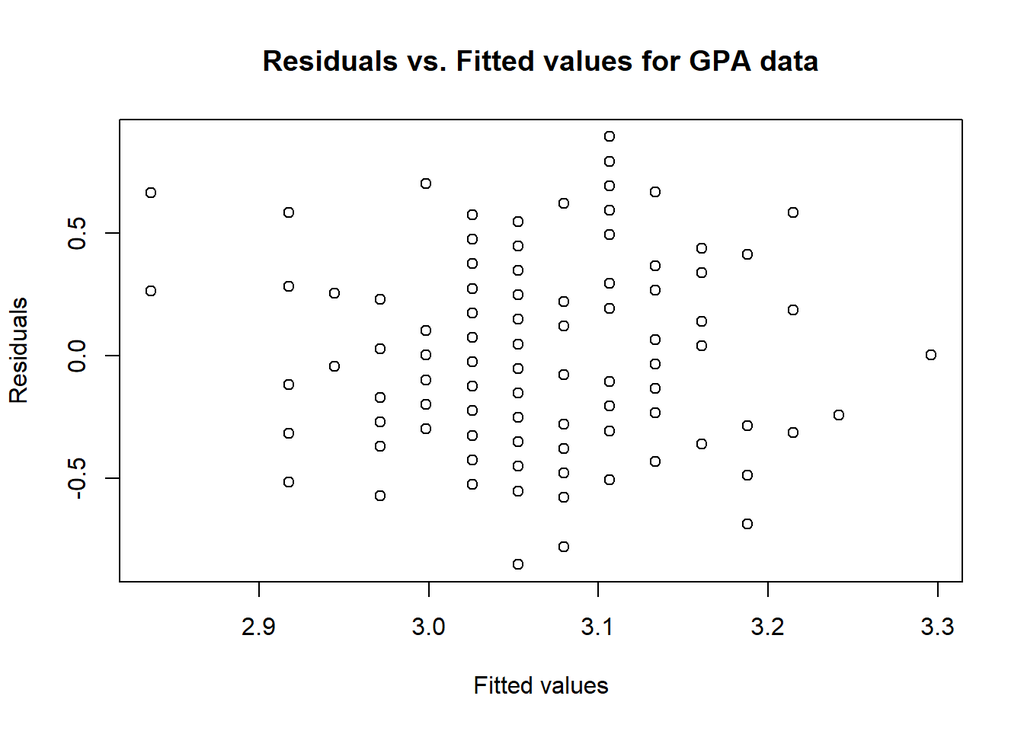

```r
plot(model1$fitted.values, model1$residuals,
     main = "Residuals vs. Fitted values for GPA data",
     xlab = "Fitted values", ylab = "Residuals")
```

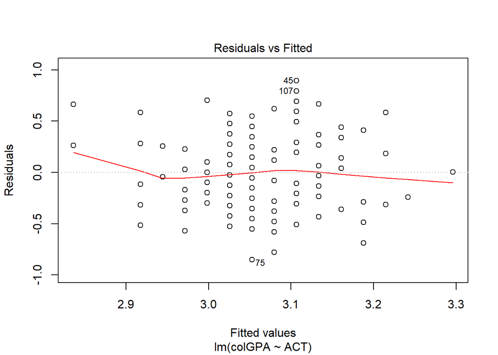

```r
# easy way to plot

plot(model1, which = 1)
```

Next, we will want to examine our data to check for any unusually influential cases. We can use a residuals vs. leverage plot for this purpose

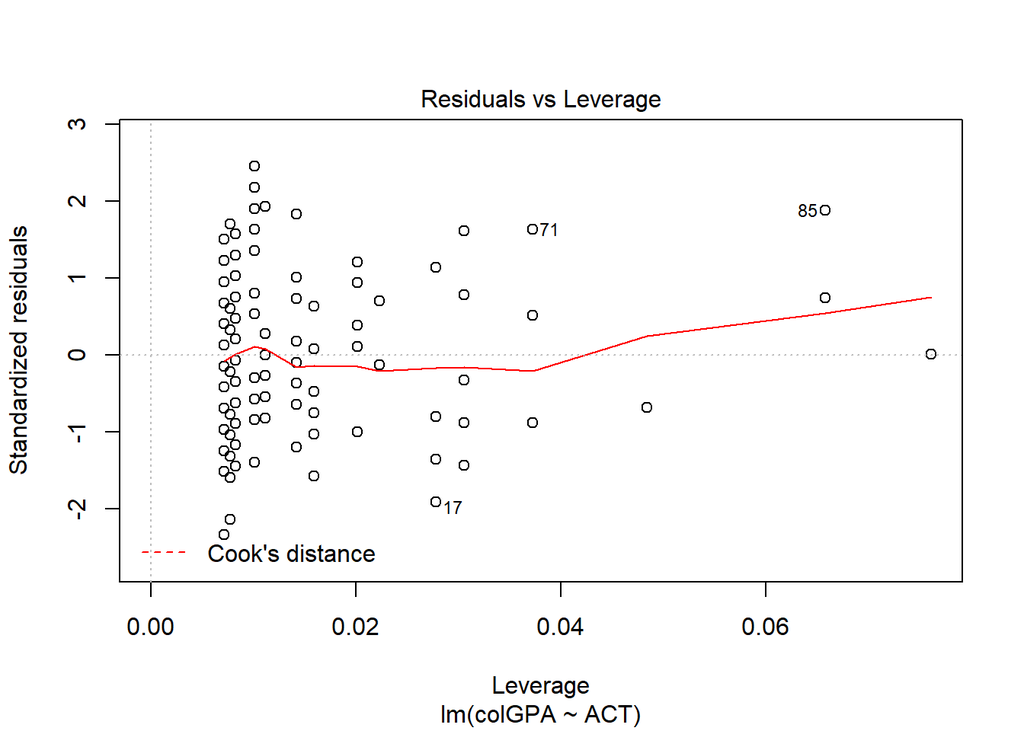

```r
plot(model1, which = 5)
```

The following code shows what would happen if we introduced an error into the data set, resulting in a point with high influence.

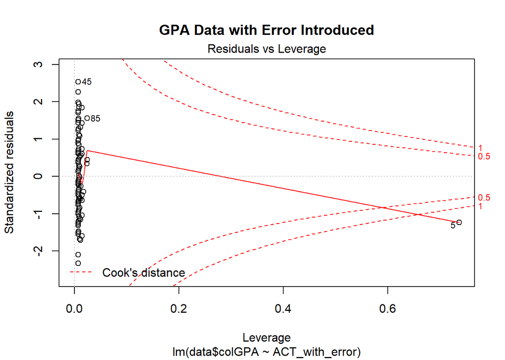

```r
ACT_with_error = data$ACT
ACT_with_error[5] = 80
model1_with_error = lm(data$colGPA ~ ACT_with_error)
plot(model1_with_error, which = 5, main = "GPA Data with Error Introduced")
```

Notice that the point now stands out as having Cook’s distance greater than 1.

We believe that our coefficients are unbiased and there are no problematic cases that should be removed from the data set.

# Multivariate Linear Model Estimation

```r
summary(data$hsGPA)
```

```
##    Min. 1st Qu.  Median    Mean 3rd Qu.    Max.
##   2.400   3.200   3.400   3.402   3.600   4.000
```

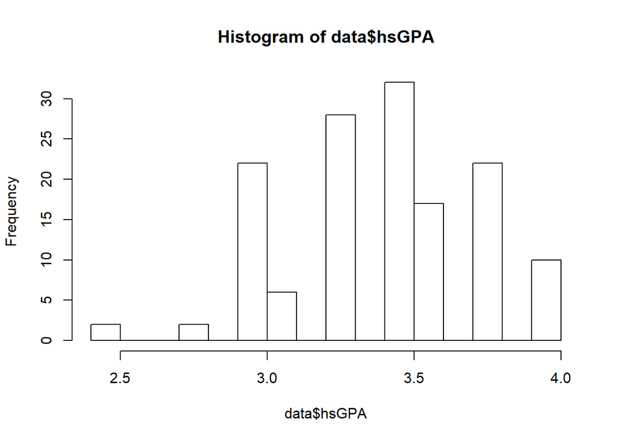

```r
hist(data$hsGPA, breaks = 20)
library(car)
```

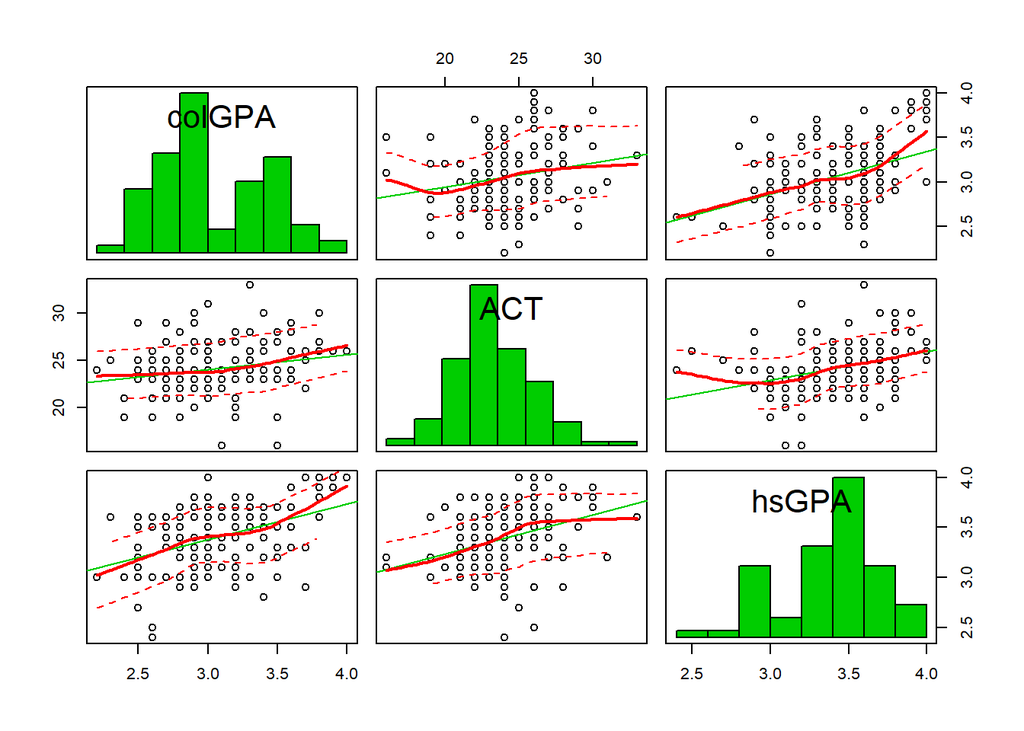

```r
scatterplotMatrix(data[,c("colGPA", "ACT", "hsGPA")], diagonal = "histogram")
```

Next, we fit the linear model.

```r
(model2 = lm(colGPA ~ ACT + hsGPA, data = data))
```

```
##
## Call:
## lm(formula = colGPA ~ ACT + hsGPA, data = data)
##
## Coefficients:
## (Intercept)          ACT        hsGPA
##    1.286328     0.009426     0.453456
```

Once again, let’s look at the residuals versus fitted values plot

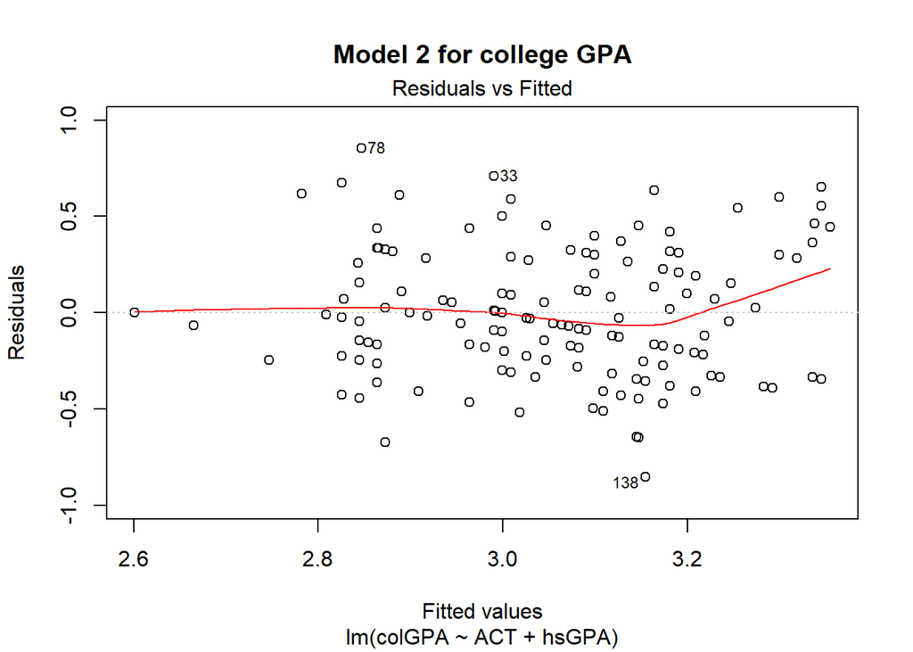

```r
plot(model2, which = 1, main = "Model 2 for college GPA")
```

Let’s compare the R-squares for our two models

```r
summary(model1)$r.square
```

```
## [1] 0.04274732
```

```r
summary(model2)$r.square
```

```
## [1] 0.1764216
```

Remember that R-squared can only go up when adding new variables

For an assessment of model fit that penalizes extra variables, we can use the Akaike Information Criterion (AIC) or the Bayesian Information Criterian (BIC)

```r
AIC(model1)
```

```
## [1] 120.3534
```

```r
AIC(model2)
```

```
## [1] 101.1457
```

```r
# lower AIC value is better fit
```

# Presenting Regression Output

For a lot of reasons, we usually want to display the results of more than one linear model.

1. There can be good arguments for different specifications
2. We want to show that an effect is robust across models
3. We want to show that we’re not cherry-picking a model that supports our argument

Because of these reasons, we often want to present the results of multiple models in a *regression table*. The stargazer package is a great way to create these tables.

```r
library("stargazer")
stargazer(model1, model2, type = "text", report = "vc",
          header = FALSE,
          title = "Linear Models Predicting College GPA",
          keep.stat = c("aic", "rsq", "n"),
          omit.table.layout = "n")
```

```
##
## Linear Models Predicting College GPA
## =================================
##              Dependent variable:
##              --------------------
##                     colGPA
##                 (1)        (2)
## ---------------------------------
## ACT            0.027      0.009
##
## hsGPA                     0.453
##
## Constant       2.403      1.286
##
## ---------------------------------
## Observations    141        141
## R2             0.043      0.176
## =================================
```